# Library Yang Digunakan untuk Peramalan Data Deret Waktu

```r
library("forecast")
```

```r
library("graphics")
library("TTR")
library("TSA")
library("readxl")
```

# Import Data

```r
data <- read_excel("C:/Users/mhdha/Downloads/JKSE_Close_Weekly.xlsx", sheet = "Sheet2")
head(data)
```

```
## # A tibble: 6 × 2
##   Date                Close
##   <dttm>              <dbl>
## 1 2015-08-17 00:00:00 4336.
## 2 2015-08-24 00:00:00 4446.
## 3 2015-08-31 00:00:00 4415.
## 4 2015-09-07 00:00:00 4360.
## 5 2015-09-14 00:00:00 4380.
## 6 2015-09-21 00:00:00 4209.
```

# Eksplorasi Data

`View()` : menampilkan data dalam bentuk tabel `str()` : menampilkan struktur data `dim()` : menampilkan dimensi dari data yang kita miliki

```r
View(data)
str(data)
```

```
## tibble [258 × 2] (S3: tbl_df/tbl/data.frame)
##  $ Date : POSIXct[1:258], format: "2015-08-17" "2015-08-24" ...
##  $ Close: num [1:258] 4336 4446 4415 4360 4380 ...
```

```r
dim(data)
```

```
## [1] 258   2
```

Mengubah data agar terbaca sebagai data deret waktu menggunakan fungsi `ts()`

```r
data.ts <- ts(data$`Close`)
```

Menampilkan ringkasan data

```r
summary(data.ts)
```

```
##    Min. 1st Qu.  Median    Mean 3rd Qu.    Max.
##    4195    5043    5788    5607    6185    6661
```

Membuat plot data deret waktu

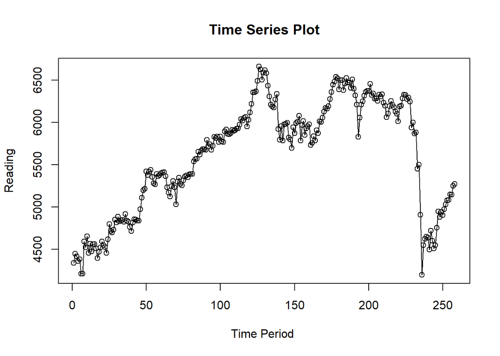

```r
ts.plot(data.ts, xlab="Time Period ", ylab="Reading",
        main = "Time Series Plot")
points(data.ts)
```

```r
#menyimpan plot
dev.copy(png, "plot_data.png")
```

```r
dev.off()
```

# Single Moving Average & Double Moving Average

## Pembagian Data

Pembagian data latih dan data uji dilakukan dengan perbandingan 80% data latih dan 20% data uji

```r
# hitung jumlah data
n <- nrow(data)

# tentukan batas 80%
n_train <- floor(0.8 * n)

# bagi data
training_ma <- data[1:n_train, ]
testing_ma  <- data[(n_train+1):n, ]

# ubah ke time series
train_ma.ts <- ts(training_ma$`Close`)
test_ma.ts  <- ts(testing_ma$`Close`)
```

Eksplorasi data dilakukan pada keseluruhan data, data latih serta data uji menggunakan plot data deret waktu

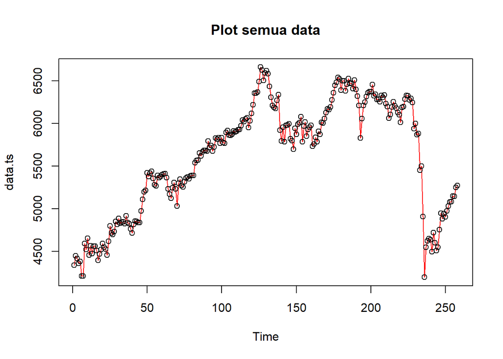

```r
#eksplorasi keseluruhan data
plot(data.ts, col="red",main="Plot semua data")
points(data.ts)
```

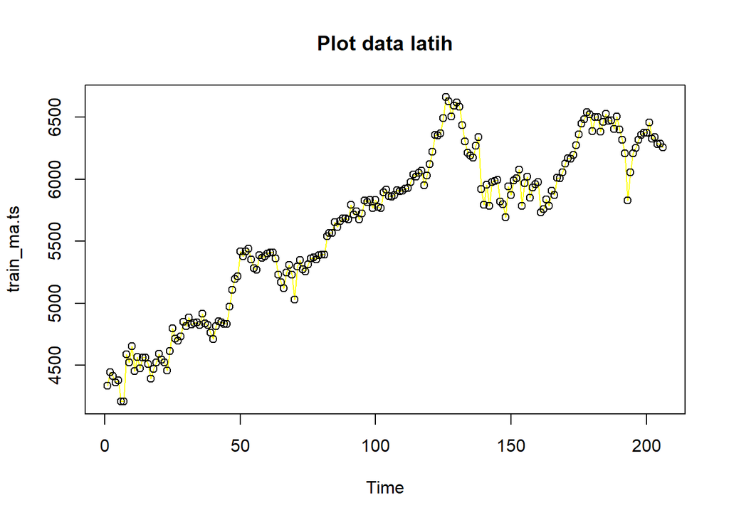

```r
#eksplorasi data latih
plot(train_ma.ts, col="yellow",main="Plot data latih")
points(train_ma.ts)
```

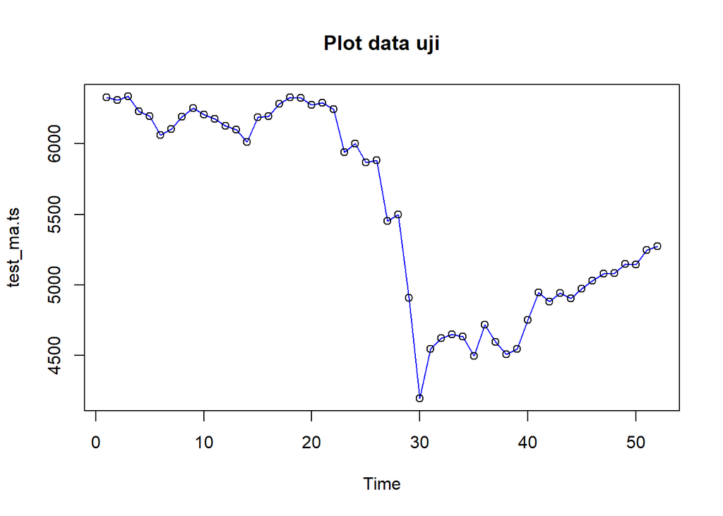

```r
#eksplorasi data uji
plot(test_ma.ts, col="blue",main="Plot data uji")
points(test_ma.ts)
```

Eksplorasi data juga dapat dilakukan menggunakan package `ggplot2` dengan terlebih dahulu memanggil library *package* `ggplot2`

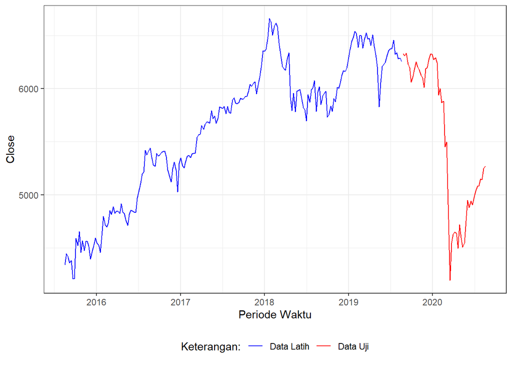

```r
library(ggplot2)
ggplot() +
  geom_line(data = training_ma, aes(x = `Date`, y = `Close`, col = "Data Latih")) +
  geom_line(data = testing_ma, aes(x = `Date`, y = `Close`, col = "Data Uji")) +
  labs(x = "Periode Waktu", y = "Close", color = "Legend") +
   scale_colour_manual(name="Keterangan:", breaks = c("Data Latih", "Data Uji"),
                      values = c("blue", "red")) +
  theme_bw() + theme(legend.position = "bottom",
                     plot.caption = element_text(hjust=0.5, size=12))
```

## Single Moving Average (SMA)

Ide dasar dari Single Moving Average (SMA) adalah data suatu periode dipengaruhi oleh data periode sebelumnya. Metode pemulusan ini cocok digunakan untuk pola data stasioner atau konstan. Prinsip dasar metode pemulusan ini adalah data pemulusan pada periode ke-t merupakan rata rata dari m buah data pada periode ke-t hingga periode ke (t-m+1)

$$S_t = \frac{1}{m} \sum_{i=t-m+1}^{t} X_i$$

Data pemulusan pada periode ke-t selanjutnya digunakan sebagai nilai peramalan pada periode ke t+1.

$$F_t = S_{t-1}, F_{n,h} = S_n$$

Pemulusan menggunakan metode SMA dilakukan dengan fungsi `SMA()`. Dalam hal ini akan dilakukan pemulusan dengan parameter `m=4`

```r
data.sma<-SMA(train_ma.ts, n=4)
data.sma
```

```
## Time Series:
## Start = 1
## End = 206
## Frequency = 1
##   [1]       NA       NA       NA 4389.320 4400.411 4341.223 4289.339 4346.556
##   [9] 4381.945 4492.868 4554.711 4549.013 4536.752 4513.800 4540.144 4525.620
##  [17] 4505.792 4482.623 4473.146 4494.284 4532.474 4546.304 4529.828 4535.366
##  [25] 4598.528 4646.131 4706.332 4735.828 4748.811 4773.657 4820.692 4844.176
##  [33] 4842.251 4850.482 4834.948 4856.859 4855.709 4849.682 4834.219 4783.507
##  [41] 4777.544 4785.375 4806.960 4837.775 4842.734 4872.148 4937.676 5028.199
##  [49] 5123.552 5235.714 5302.465 5357.159 5412.866 5396.171 5372.352 5335.287
##  [57] 5322.807 5325.642 5349.449 5382.477 5387.560 5398.939 5395.369 5353.443
##  [65] 5293.712 5221.711 5192.535 5211.574 5226.959 5203.359 5216.048 5225.772
##  [73] 5236.105 5292.757 5296.789 5300.225 5324.897 5349.052 5367.318 5374.930
##  [81] 5379.682 5427.057 5472.364 5516.587 5582.289 5601.318 5625.653 5654.951
##  [89] 5662.424 5677.091 5708.944 5716.823 5731.590 5731.667 5714.605 5742.828
##  [97] 5760.915 5799.983 5810.430 5810.760 5801.432 5785.018 5817.122 5838.206
## [105] 5859.850 5882.595 5877.233 5876.320 5885.518 5897.583 5910.516 5914.976
## [113] 5933.583 5967.124 5991.550 6022.095 6045.061 6023.210 6025.493 6042.414
## [121] 6080.882 6181.761 6262.456 6325.117 6392.588 6468.829 6537.600 6571.464
## [129] 6596.636 6586.432 6574.806 6556.756 6485.099 6382.822 6284.490 6219.922
## [137] 6211.266 6243.015 6175.578 6079.901 6001.527 5862.931 5877.057 5924.868
## [145] 5934.067 5943.692 5899.566 5827.397 5815.009 5827.752 5875.227 5953.383
## [153] 5986.658 5964.411 5959.315 5962.045 5905.618 5942.489 5939.737 5929.261
## [161] 5899.378 5855.681 5825.567 5777.659 5821.249 5850.664 5894.429 5949.750
## [169] 5987.208 6050.258 6089.631 6128.980 6163.573 6200.619 6248.525 6319.665
## [177] 6391.751 6457.775 6497.825 6483.057 6487.691 6478.002 6443.354 6461.378
## [185] 6467.352 6459.570 6482.307 6468.478 6463.965 6447.046 6408.407 6359.220
## [193] 6189.131 6103.200 6075.614 6085.901 6208.043 6283.362 6324.452 6355.222
## [201] 6390.498 6382.150 6373.825 6351.022 6308.552 6291.142
```

Data pemulusan pada periode ke-t selanjutnya digunakan sebagai nilai peramalan pada periode ke t+1 sehingga hasil peramalan 1 periode kedepan adalah sebagai berikut

```r
data.ramal<-c(NA,data.sma)
data.ramal #forecast 1 periode ke depan
```

```
##   [1]       NA       NA       NA       NA 4389.320 4400.411 4341.223 4289.339
##   [9] 4346.556 4381.945 4492.868 4554.711 4549.013 4536.752 4513.800 4540.144
##  [17] 4525.620 4505.792 4482.623 4473.146 4494.284 4532.474 4546.304 4529.828
##  [25] 4535.366 4598.528 4646.131 4706.332 4735.828 4748.811 4773.657 4820.692
##  [33] 4844.176 4842.251 4850.482 4834.948 4856.859 4855.709 4849.682 4834.219
##  [41] 4783.507 4777.544 4785.375 4806.960 4837.775 4842.734 4872.148 4937.676
##  [49] 5028.199 5123.552 5235.714 5302.465 5357.159 5412.866 5396.171 5372.352
##  [57] 5335.287 5322.807 5325.642 5349.449 5382.477 5387.560 5398.939 5395.369
##  [65] 5353.443 5293.712 5221.711 5192.535 5211.574 5226.959 5203.359 5216.048
##  [73] 5225.772 5236.105 5292.757 5296.789 5300.225 5324.897 5349.052 5367.318
##  [81] 5374.930 5379.682 5427.057 5472.364 5516.587 5582.289 5601.318 5625.653
##  [89] 5654.951 5662.424 5677.091 5708.944 5716.823 5731.590 5731.667 5714.605
##  [97] 5742.828 5760.915 5799.983 5810.430 5810.760 5801.432 5785.018 5817.122
## [105] 5838.206 5859.850 5882.595 5877.233 5876.320 5885.518 5897.583 5910.516
## [113] 5914.976 5933.583 5967.124 5991.550 6022.095 6045.061 6023.210 6025.493
## [121] 6042.414 6080.882 6181.761 6262.456 6325.117 6392.588 6468.829 6537.600
## [129] 6571.464 6596.636 6586.432 6574.806 6556.756 6485.099 6382.822 6284.490
## [137] 6219.922 6211.266 6243.015 6175.578 6079.901 6001.527 5862.931 5877.057
## [145] 5924.868 5934.067 5943.692 5899.566 5827.397 5815.009 5827.752 5875.227
## [153] 5953.383 5986.658 5964.411 5959.315 5962.045 5905.618 5942.489 5939.737
## [161] 5929.261 5899.378 5855.681 5825.567 5777.659 5821.249 5850.664 5894.429
## [169] 5949.750 5987.208 6050.258 6089.631 6128.980 6163.573 6200.619 6248.525
## [177] 6319.665 6391.751 6457.775 6497.825 6483.057 6487.691 6478.002 6443.354
## [185] 6461.378 6467.352 6459.570 6482.307 6468.478 6463.965 6447.046 6408.407
## [193] 6359.220 6189.131 6103.200 6075.614 6085.901 6208.043 6283.362 6324.452
## [201] 6355.222 6390.498 6382.150 6373.825 6351.022 6308.552 6291.142
```

Selanjutnya dilakukan peramalan sebanyak 52 periode sesuai dengan jumlah data uji. Pada metode SMA, seluruh hasil peramalan untuk 52 periode ke depan akan memiliki nilai yang sama dengan hasil ramalan satu periode ke depan.

```r
data.gab<-cbind(
  aktual=c(data.ts),
  pemulusan=c(data.sma,rep(NA,52)),
  ramalan=c(data.ramal,rep(data.ramal[length(data.ramal)],51)))

data.gab #forecast 52 periode ke depan
```

```
##          aktual pemulusan  ramalan
##   [1,] 4335.785        NA       NA
##   [2,] 4446.028        NA       NA
##   [3,] 4415.171        NA       NA
##   [4,] 4360.298  4389.320       NA
##   [5,] 4380.149  4400.411 4389.320
##   [6,] 4209.275  4341.223 4400.411
##   [7,] 4207.635  4289.339 4341.223
##   [8,] 4589.166  4346.556 4289.339
##   [9,] 4521.706  4381.945 4346.556
##  [10,] 4652.965  4492.868 4381.945
##  [11,] 4455.007  4554.711 4492.868
##  [12,] 4566.374  4549.013 4554.711
##  [13,] 4472.664  4536.752 4549.013
##  [14,] 4561.157  4513.800 4536.752
```

[output cut: 244 more lines]

Adapun plot data deret waktu dari hasil peramalan yang dilakukan adalah sebagai berikut

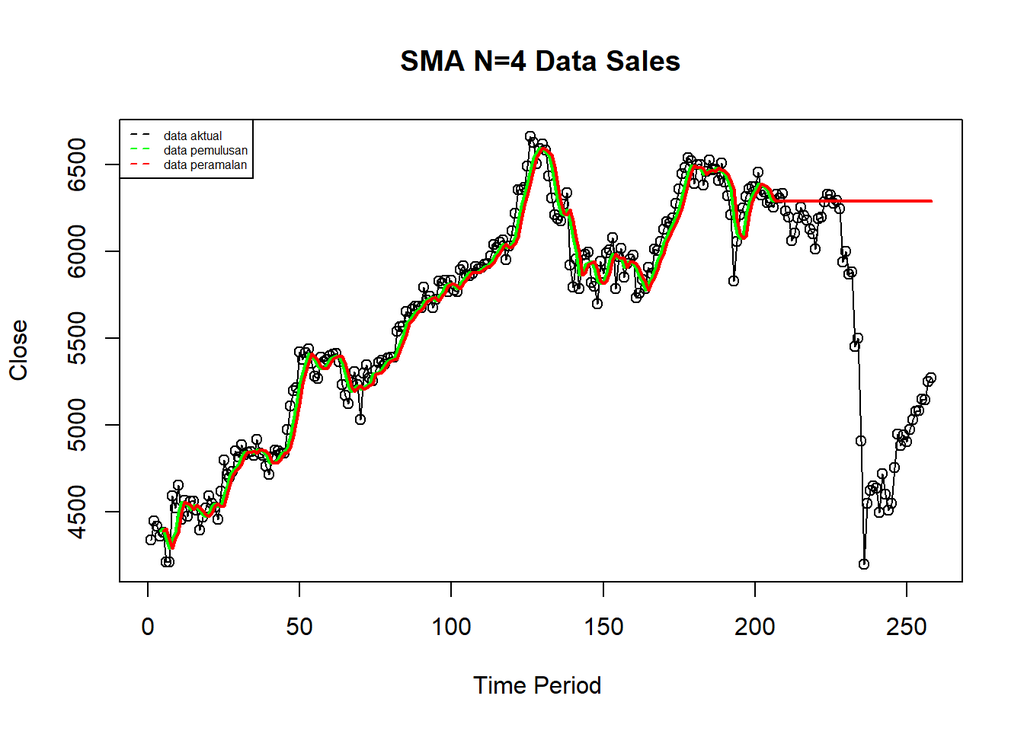

```r
ts.plot(data.ts, xlab="Time Period ", ylab="Close", main= "SMA N=4 Data Sales")
points(data.ts)
lines(data.gab[,2],col="green",lwd=2)
lines(data.gab[,3],col="red",lwd=2)
legend("topleft",c("data aktual","data pemulusan","data peramalan"), lty=8, col=c("black","green","red"), cex=0.5)
```

Selanjutnya perhitungan akurasi dilakukan dengan ukuran akurasi *Sum Squares Error* (SSE), *Mean Square Error* (MSE) dan *Mean Absolute Percentage Error* (MAPE). Perhitungan akurasi dilakukan baik pada data latih maupun pada data uji

$$SSE = \sum_{t=1}^{n} (y_t - \hat{y}_t)^2$$

$$MSE = \frac{1}{n} \sum_{t=1}^{n} (y_t - \hat{y}_t)^2$$

$$MAPE = \frac{1}{n} \sum_{t=1}^{n} \left|\frac{y_t -
\hat{y}_t}{y_t}\right| * 100$$

```r
#Menghitung nilai keakuratan data latih
error_train.sma = train_ma.ts-data.ramal[1:length(train_ma.ts)]

SSE_train.sma = sum(error_train.sma[5:length(train_ma.ts)]^2)
MSE_train.sma = mean(error_train.sma[5:length(train_ma.ts)]^2)
MAPE_train.sma = mean(abs((error_train.sma[5:length(train_ma.ts)]/train_ma.ts[5:length(train_ma.ts)])*100))

akurasi_train.sma <- matrix(c(SSE_train.sma, MSE_train.sma, MAPE_train.sma))
row.names(akurasi_train.sma)<- c("SSE", "MSE", "MAPE")
colnames(akurasi_train.sma) <- c("Akurasi m = 4")
akurasi_train.sma
```

```
##      Akurasi m = 4
## SSE   3.106497e+06
## MSE   1.537870e+04
## MAPE  1.688865e+00
```

Dalam hal ini nilai MAPE data latih pada metode pemulusan SMA sekitar 1.7%, nilai ini dapat dikategorikan sebagai nilai akurasi yang sangat baik. Selanjutnya dilakukan perhitungan nilai MAPE data uji pada metode pemulusan SMA.

```r
#Menghitung nilai keakuratan data uji
error_test.sma = test_ma.ts-data.gab[207:258,3]

SSE_test.sma = sum(error_test.sma^2)
MSE_test.sma = mean(error_test.sma^2)
MAPE_test.sma = mean(abs((error_test.sma/test_ma.ts*100)))

akurasi_test.sma <- matrix(c(SSE_test.sma, MSE_test.sma, MAPE_test.sma))
row.names(akurasi_test.sma)<- c("SSE", "MSE", "MAPE")
colnames(akurasi_test.sma) <- c("Akurasi m = 4")
akurasi_test.sma
```

```
##      Akurasi m = 4
## SSE   5.545803e+07
## MSE   1.066501e+06
## MAPE  1.587474e+01
```

## Double Moving Average (DMA)

Metode pemulusan Double Moving Average (DMA) pada dasarnya mirip dengan SMA. Namun demikian, metode ini lebih cocok digunakan untuk pola data trend. Proses pemulusan dengan rata rata dalam metode ini dilakukan sebanyak 2 kali

- **Tahap I:**
  $$S_{1,t} = \frac{1}{m} \sum_{i=t-m+1}^{t} X_i$$
- **Tahap II:**
  $$S_{2,t} = \frac{1}{m} \sum_{i=t-m+1}^{t} S_{1,i}$$

Forecast $h$ langkah ke depan dihitung dengan:
$$F_{2,t,t+h} = A_t + B_t \,(h)$$

dengan komponen level ($A_t$) dan tren ($B_t$):
$$A_t = 2S_{1,t} - S_{2,t}
\qquad\text{dan}\qquad
B_t = \frac{2}{m-1}\,\big(S_{1,t} - S_{2,t}\big)$$

```r
dma <- SMA(data.sma, n = 4)
At <- 2*data.sma - dma
Bt <- 2/(4-1)*(data.sma - dma)
data.dma<- At+Bt
data.ramal<- c(NA, data.dma)

t = 1:52
f = c()

for (i in t) {
  f[i] = At[length(At)] + Bt[length(Bt)]*(i)
}

data.gab <- cbind(aktual = c(data.ts),
                   pemulusan1 = c(data.sma,rep(NA,52)),
                   pemulusan2 = c(dma, rep(NA,52)),
                   At = c(At, rep(NA,52)),
                   Bt = c(Bt,rep(NA,52)),
                   ramalan = c(data.ramal, f[-1]))
data.gab
```

```
##          aktual pemulusan1 pemulusan2       At            Bt  ramalan
##   [1,] 4335.785         NA         NA       NA            NA       NA
##   [2,] 4446.028         NA         NA       NA            NA       NA
##   [3,] 4415.171         NA         NA       NA            NA       NA
##   [4,] 4360.298   4389.320         NA       NA            NA       NA
##   [5,] 4380.149   4400.411         NA       NA            NA       NA
##   [6,] 4209.275   4341.223         NA       NA            NA       NA
##   [7,] 4207.635   4289.339   4355.074 4223.605  -43.82295736       NA
##   [8,] 4589.166   4346.556   4344.382 4348.730    1.44905599 4179.782
##   [9,] 4521.706   4381.945   4339.766 4424.125   28.11954753 4350.179
##  [10,] 4652.965   4492.868   4377.677 4608.058   76.79378255 4452.244
##  [11,] 4455.007   4554.711   4444.020 4665.401   73.79386393 4684.852
##  [12,] 4566.374   4549.013   4494.634 4603.392   36.25248210 4739.195
##  [13,] 4472.664   4536.752   4533.336 4540.169    2.27762858 4639.644
##  [14,] 4561.157   4513.800   4538.569 4489.032  -16.51249186 4542.446
```

[output cut: 244 more lines]

Hasil pemulusan menggunakan metode DMA divisualisasikan sebagai berikut

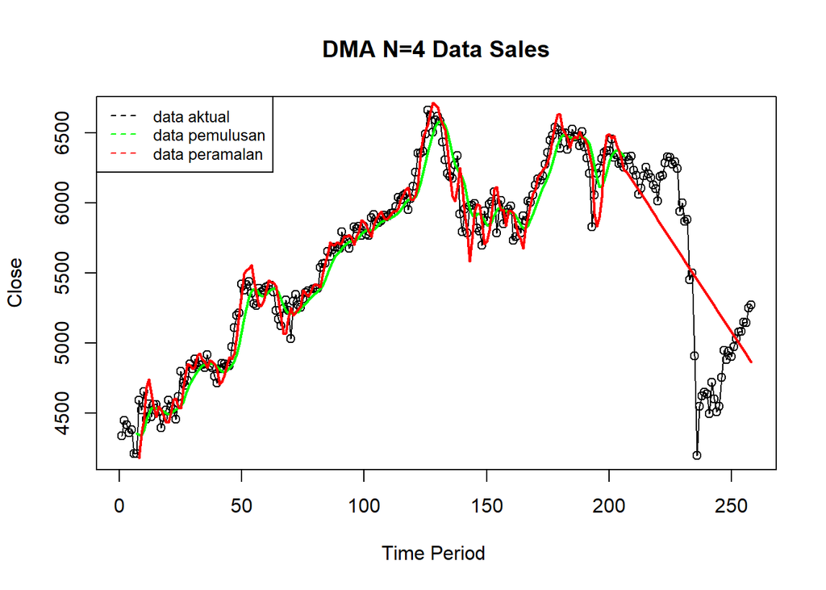

```r
ts.plot(data.ts, xlab="Time Period ", ylab="Close", main= "DMA N=4 Data Sales")
points(data.ts)
lines(data.gab[,3],col="green",lwd=2)
lines(data.gab[,6],col="red",lwd=2)
legend("topleft",c("data aktual","data pemulusan","data peramalan"), lty=8, col=c("black","green","red"), cex=0.8)
```

Selanjutnya perhitungan akurasi dilakukan baik pada data latih maupun data uji. Perhitungan akurasi dilakukan dengan ukuran akurasi SSE, MSE dan MAPE

```r
#Menghitung nilai keakuratan data latih
error_train.dma = train_ma.ts-data.ramal[1:length(train_ma.ts)]

SSE_train.dma = sum(error_train.dma[8:length(train_ma.ts)]^2)
MSE_train.dma = mean(error_train.dma[8:length(train_ma.ts)]^2)
MAPE_train.dma = mean(abs((error_train.dma[8:length(train_ma.ts)]/train_ma.ts[8:length(train_ma.ts)])*100))

akurasi_train.dma <- matrix(c(SSE_train.dma, MSE_train.dma, MAPE_train.dma))
row.names(akurasi_train.dma)<- c("SSE", "MSE", "MAPE")
colnames(akurasi_train.dma) <- c("Akurasi m = 4")
akurasi_train.dma
```

```
##      Akurasi m = 4
## SSE   3.263231e+06
## MSE   1.639815e+04
## MAPE  1.689832e+00
```

Perhitungan akurasi pada data latih menggunakan nilai MAPE menghasilkan nilai MAPE yang kurang dari 10% sehingga dikategorikan sangat baik. Selanjutnya, perhitungan nilai akurasi dilakukan pada data uji.

```r
#Menghitung nilai keakuratan data uji
error_test.dma = test_ma.ts-data.gab[207:258,6]
SSE_test.dma = sum(error_test.dma^2)
MSE_test.dma = mean(error_test.dma^2)
MAPE_test.dma = mean(abs((error_test.dma/test_ma.ts*100)))

akurasi_test.dma <- matrix(c(SSE_test.dma, MSE_test.dma, MAPE_test.dma))
row.names(akurasi_test.dma)<- c("SSE", "MSE", "MAPE")
colnames(akurasi_test.dma) <- c("Akurasi m = 4")
akurasi_test.dma
```

```
##      Akurasi m = 4
## SSE   1.040654e+07
## MSE   2.001258e+05
## MAPE  6.890134e+00
```

# Single Exponential Smoothing & Double Exponential Smoothing

Metode Exponential Smoothing merupakan metode pemulusan deret waktu dengan memberikan bobot yang menurun secara eksponensial pada data historis, di mana nilai terbaru mendapat bobot lebih besar dibanding nilai yang lebih lama. Metode ini menggunakan satu atau lebih parameter pemulusan yang secara langsung menentukan besar kecilnya bobot setiap pengamatan. Pemilihan parameter yang tepat akan sangat berpengaruh terhadap hasil ramalan. Secara umum, Exponential Smoothing dibedakan menjadi dua jenis, yaitu model tunggal (single) yang digunakan untuk data tanpa tren maupun musiman, serta model ganda (double) yang mampu menangkap adanya tren pada data

## Pembagian Data

```r
# jumlah baris data
n <- nrow(data)

# hitung batas 80%
n_train <- floor(0.8 * n)

# bagi data
training <- data[1:n_train, ]
testing  <- data[(n_train+1):n, ]

# ubah ke time series
train.ts <- ts(training$`Close`)
test.ts  <- ts(testing$`Close`)
```

## Eksplorasi

Eksplorasi dilakukan dengan membuat plot data deret waktu untuk keseluruhan data, data latih, dan data uji

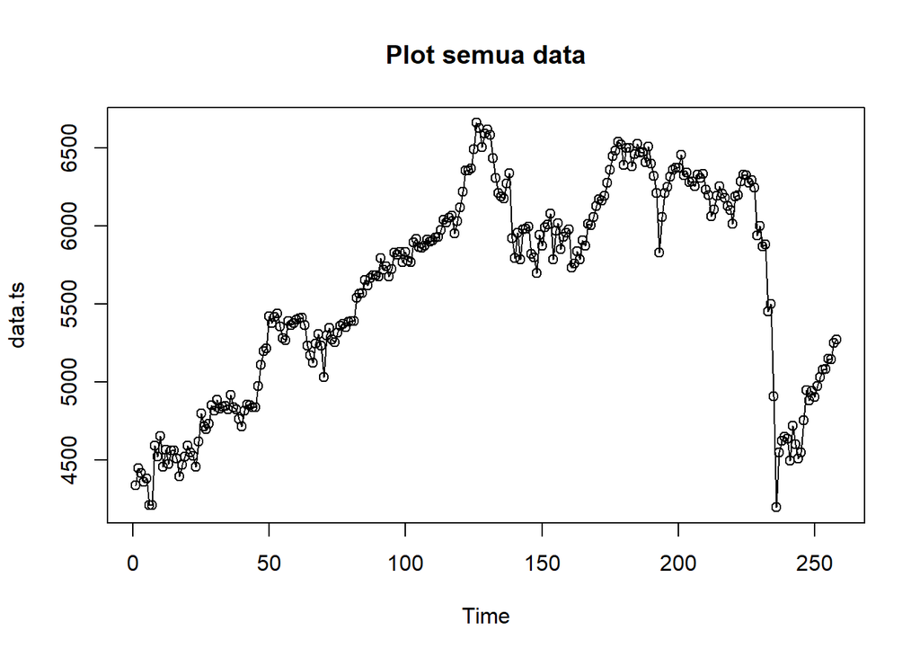

```r
#eksplorasi data
plot(data.ts, col="black",main="Plot semua data")
points(data.ts)
```

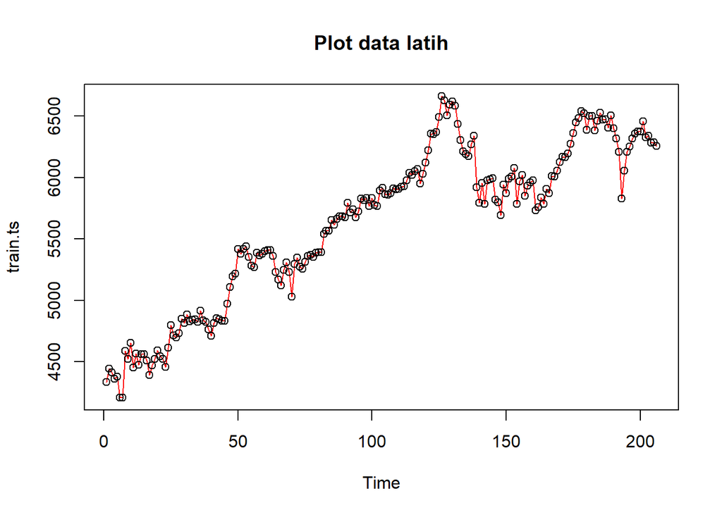

```r
plot(train.ts, col="red",main="Plot data latih")
points(train.ts)
```

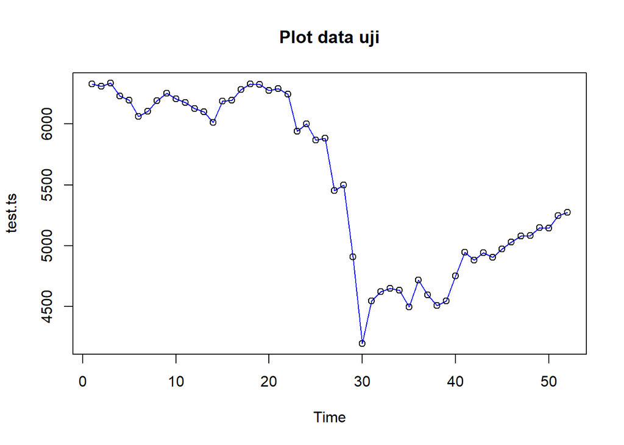

```r
plot(test.ts, col="blue",main="Plot data uji")
points(test.ts)
```

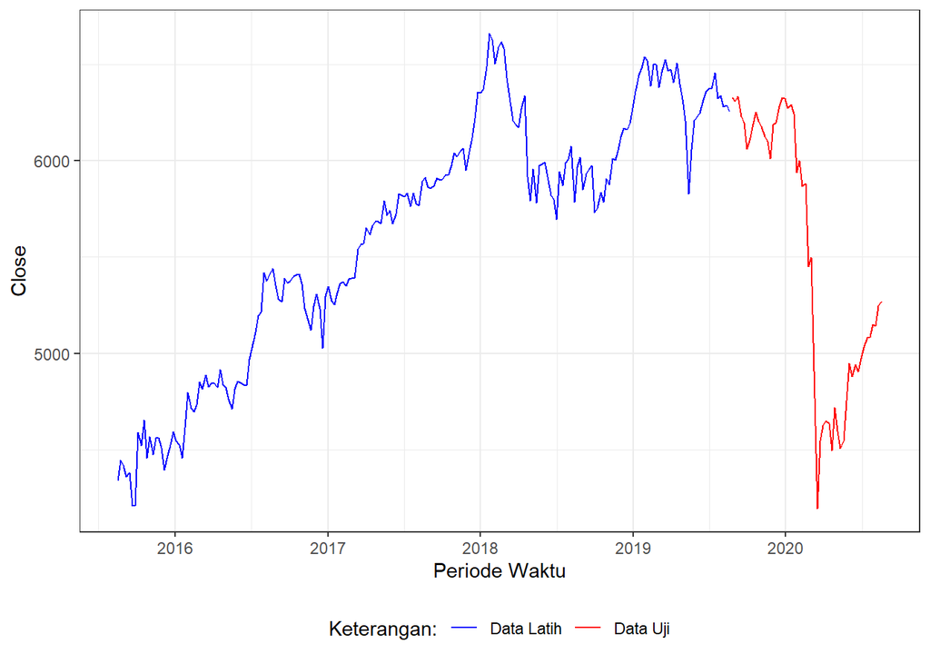

```r
#Eksplorasi dengan GGPLOT
library(ggplot2)
ggplot() +
  geom_line(data = training, aes(x = `Date`, y = `Close`, col = "Data Latih")) +
  geom_line(data = testing, aes(x = `Date`, y = `Close`, col = "Data Uji")) +
  labs(x = "Periode Waktu", y = "Close", color = "Legend") +
  scale_colour_manual(name="Keterangan:", breaks = c("Data Latih", "Data Uji"),
                      values = c("blue", "red")) +
  theme_bw() + theme(legend.position = "bottom",
                     plot.caption = element_text(hjust=0.5, size=12))
```

## Single Exponential Smoothing

Single Exponential Smoothing (SES) adalah metode peramalan deret waktu yang dikembangkan untuk mengatasi kelemahan Moving Average. Jika pada Moving Average setiap data periode sebelumnya dianggap memiliki bobot yang sama, maka SES memberikan bobot yang semakin mengecil secara eksponensial terhadap data lama, sehingga data terbaru diberi bobot lebih besar.

Single Exponential Smoothing merupakan metode pemulusan yang tepat digunakan untuk data dengan pola stasioner atau konstan.

Nilai pemulusan pada periode ke-t didapat dari persamaan:

$$\tilde{y}_T=\lambda
y_t+(1-\lambda)\tilde{y}_{T-1}$$

Nilai parameter $\lambda$ adalah nilai antara 0 dan 1.

Nilai pemulusan periode ke-t bertindak sebagai nilai ramalan pada periode ke-$(T+\tau)$.

$$\tilde{y}_{T+\tau}(T)=\tilde{y}_T$$

Pemulusan dengan metode SES dapat dilakukan dengan dua fungsi dari *packages* berbeda, yaitu (1) fungsi `ses()` dari *packages* `forecast` dan (2) fungsi `HoltWinters` dari *packages* `stats`

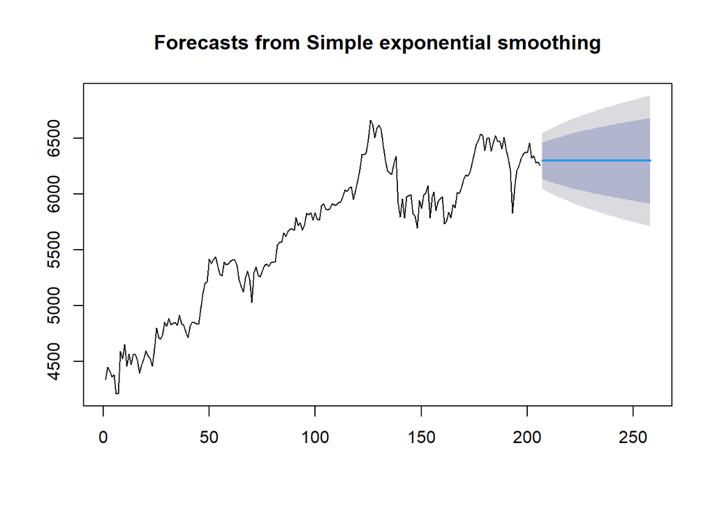

```r
#Cara 1 (fungsi ses)
ses.1 <- ses(train.ts, h = 52, alpha = 0.3)
plot(ses.1)
```

```r
ses.1
```

```
##     Point Forecast    Lo 80    Hi 80    Lo 95    Hi 95
## 207       6297.692 6135.666 6459.718 6049.895 6545.489
## 208       6297.692 6128.532 6466.852 6038.984 6556.400
## 209       6297.692 6121.687 6473.697 6028.515 6566.868
## 210       6297.692 6115.098 6480.286 6018.439 6576.945
## 211       6297.692 6108.739 6486.645 6008.713 6586.670
## 212       6297.692 6102.587 6492.797 5999.305 6596.079
## 213       6297.692 6096.623 6498.761 5990.184 6605.200
## 214       6297.692 6090.831 6504.552 5981.326 6614.058
## 215       6297.692 6085.197 6510.187 5972.709 6622.675
## 216       6297.692 6079.709 6515.675 5964.315 6631.069
## 217       6297.692 6074.355 6521.029 5956.127 6639.256
## 218       6297.692 6069.126 6526.257 5948.131 6647.253
## 219       6297.692 6064.015 6531.369 5940.314 6655.070
## 220       6297.692 6059.013 6536.371 5932.664 6662.720
```

[output cut: 38 more lines]

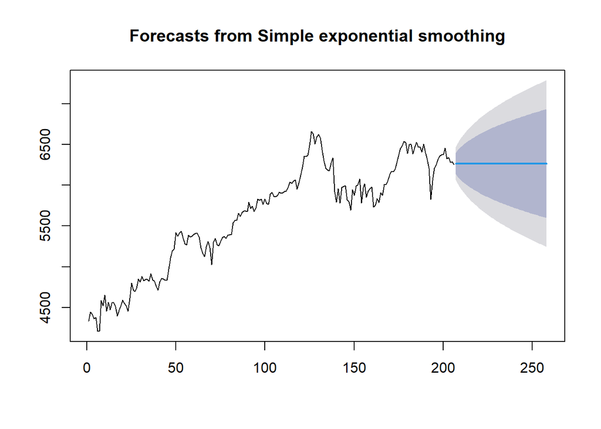

```r
ses.2<- ses(train.ts, h = 52, alpha = 0.7)
plot(ses.2)
```

```r
ses.2
```

```
##     Point Forecast    Lo 80    Hi 80    Lo 95    Hi 95
## 207        6266.21 6135.318 6397.103 6066.027 6466.393
## 208        6266.21 6106.436 6425.985 6021.856 6510.564
## 209        6266.21 6082.028 6450.392 5984.528 6547.892
## 210        6266.21 6060.497 6471.924 5951.598 6580.822
## 211        6266.21 6041.014 6491.406 5921.803 6610.618
## 212        6266.21 6023.088 6509.332 5894.387 6638.033
## 213        6266.21 6006.396 6526.024 5868.859 6663.562
## 214        6266.21 5990.713 6541.707 5844.874 6687.546
## 215        6266.21 5975.877 6556.544 5822.183 6710.237
## 216        6266.21 5961.762 6570.658 5800.597 6731.824
## 217        6266.21 5948.273 6584.147 5779.968 6752.453
## 218        6266.21 5935.334 6597.086 5760.179 6772.241
## 219        6266.21 5922.882 6609.538 5741.136 6791.285
## 220        6266.21 5910.867 6621.554 5722.759 6809.661
```

[output cut: 38 more lines]

Pada fungsi `ses()` , terdapat beberapa argumen yang umum digunakan, yaitu

- `y` : nilai data deret waktu
- `alpha` : parameter pemulusan utama (0–1), mengatur bobot data terbaru vs data lama.
- `beta` : parameter pemulusan tren.
- `gamma` : parameter pemulusan musiman.
- `h` : jumlah periode ke depan yang ingin diramalkan (forecast horizon).

  Kasus di atas merupakan contoh inisialisasi nilai parameter $\lambda$ dengan nilai `alpha` 0,3 dan 0,7 dan banyak periode data yang akan diramalkan adalah sebanyak 52 periode.

Untuk mendapatkan gambar hasil pemulusan pada data latih dengan fungsi `ses()` , perlu digunakan fungsi `autoplot()` dan `autolayer()` dari *library packages* `ggplot2` .

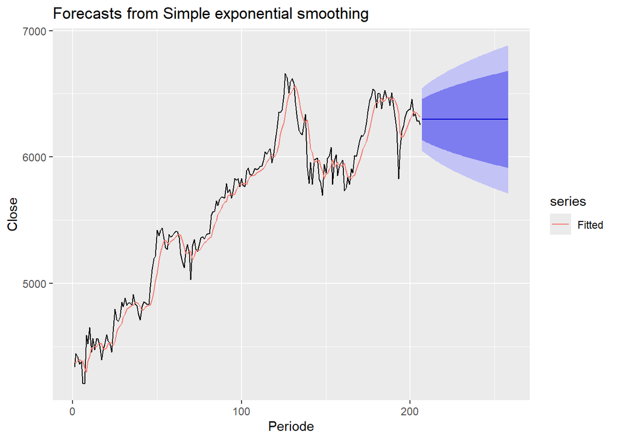

```r
autoplot(ses.1) +
  autolayer(fitted(ses.1), series="Fitted") +
  ylab("Close") + xlab("Periode")
```

Selanjutnya akan digunakan fungsi `HoltWinters()` dengan nilai inisialisasi parameter dan panjang periode peramalan yang sama dengan fungsi `ses()` .

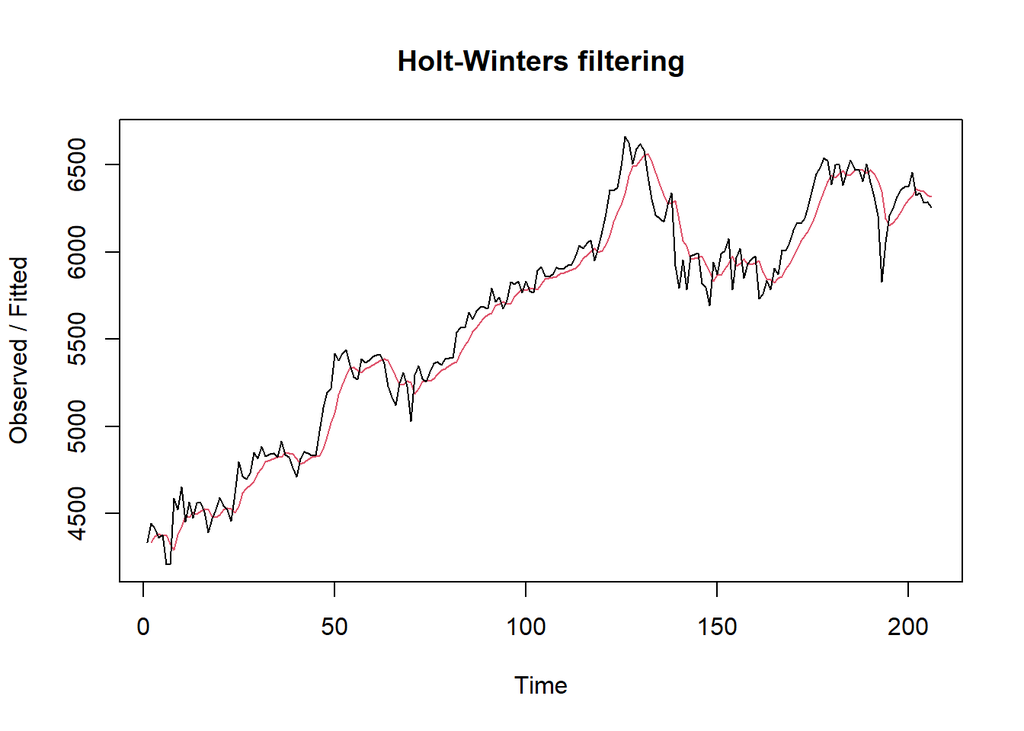

```r
#Cara 2 (fungsi Holtwinter)
ses1<- HoltWinters(train.ts, gamma = FALSE, beta = FALSE, alpha = 0.3)
plot(ses1)
```

```r
#ramalan
ramalan1<- forecast(ses1, h=52)
ramalan1
```

```
##     Point Forecast    Lo 80    Hi 80    Lo 95    Hi 95
## 207       6297.692 6140.820 6454.564 6057.777 6537.607
## 208       6297.692 6133.913 6461.471 6047.213 6548.170
## 209       6297.692 6127.285 6468.098 6037.078 6558.306
## 210       6297.692 6120.906 6474.478 6027.322 6568.062
## 211       6297.692 6114.749 6480.634 6017.905 6577.478
## 212       6297.692 6108.793 6486.591 6008.796 6586.588
## 213       6297.692 6103.019 6492.365 5999.965 6595.418
## 214       6297.692 6097.411 6497.973 5991.389 6603.995
## 215       6297.692 6091.956 6503.427 5983.046 6612.337
## 216       6297.692 6086.642 6508.741 5974.919 6620.464
## 217       6297.692 6081.459 6513.925 5966.992 6628.392
## 218       6297.692 6076.397 6518.987 5959.250 6636.133
## 219       6297.692 6071.448 6523.936 5951.682 6643.702
## 220       6297.692 6066.605 6528.779 5944.275 6651.109
```

[output cut: 38 more lines]

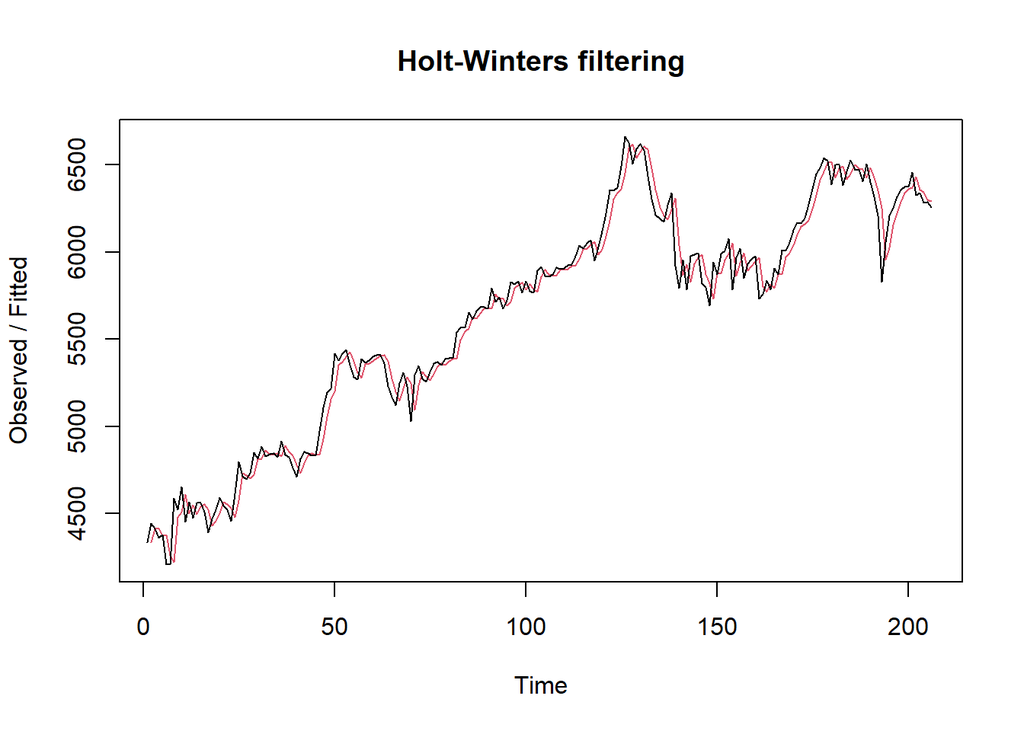

```r
ses2<- HoltWinters(train.ts, gamma = FALSE, beta = FALSE, alpha = 0.7)
plot(ses2)
```

```r
#ramalan
ramalan2<- forecast(ses2, h=52)
ramalan2
```

```
##     Point Forecast    Lo 80    Hi 80    Lo 95    Hi 95
## 207        6266.21 6136.436 6395.985 6067.737 6464.683
## 208        6266.21 6107.800 6424.620 6023.943 6508.477
## 209        6266.21 6083.601 6448.819 5986.934 6545.486
## 210        6266.21 6062.254 6470.167 5954.285 6578.135
## 211        6266.21 6042.938 6489.483 5924.744 6607.676
## 212        6266.21 6025.165 6507.256 5897.563 6634.857
## 213        6266.21 6008.615 6523.805 5872.253 6660.168
## 214        6266.21 5993.066 6539.354 5848.473 6683.948
## 215        6266.21 5978.356 6554.064 5825.976 6706.445
## 216        6266.21 5964.362 6568.058 5804.574 6727.847
## 217        6266.21 5950.989 6581.431 5784.121 6748.299
## 218        6266.21 5938.160 6594.260 5764.501 6767.919
## 219        6266.21 5925.815 6606.606 5745.620 6786.800
## 220        6266.21 5913.902 6618.519 5727.401 6805.020
```

[output cut: 38 more lines]

Fungsi `HoltWinters` memiliki argumen yang sama dengan fungsi `ses()` . Argumen-argumen kedua fungsi dapat dilihat lebih lanjut dengan `?ses()` atau `?HoltWinters` .

Nilai parameter $\alpha$ dari kedua fungsi dapat dioptimalkan menyesuaikan dari *error*-nya paling minimumnya. Caranya adalah dengan membuat parameter $\alpha =$ `NULL` .

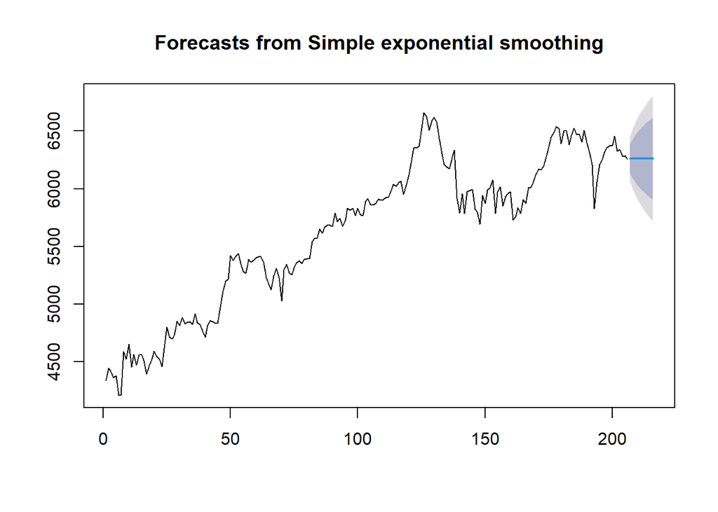

```r
#SES
ses.opt <- ses(train.ts, h = 10, alpha = NULL)
plot(ses.opt)
```

```r
ses.opt
```

```
##     Point Forecast    Lo 80    Hi 80    Lo 95    Hi 95
## 207       6260.152 6130.754 6389.550 6062.255 6458.049
## 208       6260.152 6089.825 6430.479 5999.659 6520.645
## 209       6260.152 6056.980 6463.324 5949.427 6570.877
## 210       6260.152 6028.751 6491.553 5906.255 6614.049
## 211       6260.152 6003.610 6516.694 5867.804 6652.499
## 212       6260.152 5980.721 6539.582 5832.800 6687.504
## 213       6260.152 5959.571 6560.733 5800.453 6719.851
## 214       6260.152 5939.814 6580.490 5770.237 6750.066
## 215       6260.152 5921.207 6599.097 5741.780 6778.524
## 216       6260.152 5903.569 6616.735 5714.805 6805.498
```

```r
#Lamda Optimum Holt Winter
HWopt<- HoltWinters(train.ts, gamma = FALSE, beta = FALSE,alpha = NULL)
HWopt
```

```
## Holt-Winters exponential smoothing without trend and without seasonal component.
##
## Call:
## HoltWinters(x = train.ts, alpha = NULL, beta = FALSE, gamma = FALSE)
##
## Smoothing parameters:
##  alpha: 0.8566484
##  beta : FALSE
##  gamma: FALSE
##
## Coefficients:
##       [,1]
## a 6260.129
```

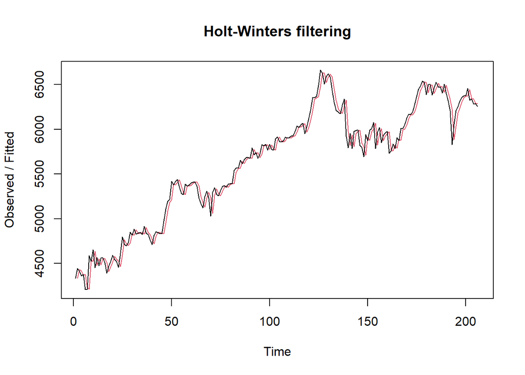

```r
plot(HWopt)
```

```r
#ramalan
ramalanopt<- forecast(HWopt, h=52)
ramalanopt
```

```
##     Point Forecast    Lo 80    Hi 80    Lo 95    Hi 95
## 207       6260.129 6131.491 6388.766 6063.395 6456.862
## 208       6260.129 6090.745 6429.512 6001.078 6519.179
## 209       6260.129 6058.054 6462.203 5951.082 6569.175
## 210       6260.129 6029.960 6490.297 5908.116 6612.141
## 211       6260.129 6004.941 6515.317 5869.852 6650.405
## 212       6260.129 5982.164 6538.093 5835.019 6685.239
## 213       6260.129 5961.118 6559.140 5802.831 6717.427
## 214       6260.129 5941.458 6578.799 5772.764 6747.493
## 215       6260.129 5922.943 6597.314 5744.447 6775.810
## 216       6260.129 5905.393 6614.865 5717.607 6802.651
## 217       6260.129 5888.671 6631.587 5692.033 6828.224
## 218       6260.129 5872.670 6647.587 5667.561 6852.696
## 219       6260.129 5857.304 6662.953 5644.061 6876.196
## 220       6260.129 5842.503 6677.754 5621.426 6898.832
```

[output cut: 38 more lines]

Setelah dilakukan peramalan, akan dilakukan perhitungan keakuratan hasil peramalan. Perhitungan akurasi ini dilakukan baik pada data latih dan data uji

### Akurasi Data Latih

Perhitungan akurasi data dapat dilakukan dengan cara langsung maupun manual. Secara langsung, nilai akurasi dapat diambil dari objek yang tersimpan pada hasil SES, yaitu *sum of squared errors* (SSE). Nilai akurasi lain dapat dihitung pula dari nilai SSE tersebut

```r
#Keakuratan Metode
#Pada data training

# SES dengan alpha = 0.3
SSE1<-ses1$SSE
MSE1<-ses1$SSE/length(train.ts)
RMSE1<-sqrt(MSE1)

akurasi1 <- matrix(c(SSE1,MSE1,RMSE1))
row.names(akurasi1)<- c("SSE", "MSE", "RMSE")
colnames(akurasi1) <- c("Akurasi lamda=0.3")
akurasi1
```

```
##      Akurasi lamda=0.3
## SSE       3265291.0317
## MSE         15850.9273
## RMSE          125.9005
```

```r
# SES dengan alpha = 0.7
SSE2<-ses2$SSE
MSE2<-ses2$SSE/length(train.ts)
RMSE2<-sqrt(MSE2)

akurasi2 <- matrix(c(SSE2,MSE2,RMSE2))
row.names(akurasi2)<- c("SSE", "MSE", "RMSE")
colnames(akurasi2) <- c("Akurasi lamda=0.7")
akurasi2
```

```
##      Akurasi lamda=0.7
## SSE       2128978.5717
## MSE         10334.8474
## RMSE          101.6605
```

```r
#Cara Manual
# Alpha = 0.3
fitted1<-ramalan1$fitted
sisaan1<-ramalan1$residuals
head(sisaan1)
```

```
## Time Series:
## Start = 1
## End = 6
## Frequency = 1
## [1]          NA  110.243652   46.313135  -22.453853    4.133377 -167.980659
```

```r
resid1<-training$`Close`-ramalan1$fitted
head(resid1)
```

```
## Time Series:
## Start = 1
## End = 6
## Frequency = 1
## [1]          NA  110.243652   46.313135  -22.453853    4.133377 -167.980659
```

```r
SSE.1=sum(sisaan1[2:length(train.ts)]^2)
SSE.1
```

```
## [1] 3265291
```

```r
MSE.1 = SSE.1/length(train.ts)
MSE.1
```

```
## [1] 15850.93
```

```r
MAPE.1 = sum(abs(sisaan1[2:length(train.ts)]/train.ts[2:length(train.ts)])*
               100)/length(train.ts)
MAPE.1
```

```
## [1] 1.70946
```

```r
akurasi.1 <- matrix(c(SSE.1,MSE.1,MAPE.1))
row.names(akurasi.1)<- c("SSE", "MSE", "MAPE")
colnames(akurasi.1) <- c("Akurasi lamda=0.3")
akurasi.1
```

```
##      Akurasi lamda=0.3
## SSE       3.265291e+06
## MSE       1.585093e+04
## MAPE      1.709460e+00
```

```r
# Alpha = 0.7
fitted2<-ramalan2$fitted
sisaan2<-ramalan2$residuals
head(sisaan2)
```

```
## Time Series:
## Start = 1
## End = 6
## Frequency = 1
## [1]          NA  110.243652    2.215674  -54.208345    3.588571 -169.797452
```

```r
resid2<-training$`Close`-ramalan2$fitted
head(resid2)
```

```
## Time Series:
## Start = 1
## End = 6
## Frequency = 1
## [1]          NA  110.243652    2.215674  -54.208345    3.588571 -169.797452
```

```r
SSE.2=sum(sisaan2[2:length(train.ts)]^2)
SSE.2
```

```
## [1] 2128979
```

```r
MSE.2 = SSE.2/length(train.ts)
MSE.2
```

```
## [1] 10334.85
```

```r
MAPE.2 = sum(abs(sisaan2[2:length(train.ts)]/train.ts[2:length(train.ts)])*
               100)/length(train.ts)
MAPE.2
```

```
## [1] 1.355234
```

```r
akurasi.2 <- matrix(c(SSE.2,MSE.2,MAPE.2))
row.names(akurasi.2)<- c("SSE", "MSE", "MAPE")
colnames(akurasi.2) <- c("Akurasi lamda=0.7")
akurasi.2
```

```
##      Akurasi lamda=0.7
## SSE       2.128979e+06
## MSE       1.033485e+04
## MAPE      1.355234e+00
```

Berdasarkan nilai SSE, MSE, RMSE, dan MAPE di antara kedua parameter, nilai parameter $\lambda=0,7$ menghasilkan akurasi yang lebih baik dibanding $\lambda=0,3$ . Hal ini dilihat dari nilai masing-masing ukuran akurasi yang lebih kecil. Berdasarkan nilai MAPE-nya, hasil ini dapat dikategorikan sebagai peramalan sangat baik.

### Akurasi Data Uji

Akurasi data uji dapat dihitung dengan cara yang hampir sama dengan perhitungan akurasi data latih.

```r
# jumlah observasi uji
n_test <- nrow(testing)

# error (ramalan - aktual), samakan panjang dan tipe numeric
e1   <- as.numeric(ramalan1$mean)[1:n_test] - as.numeric(testing$`Close`)
e2   <- as.numeric(ramalan2$mean)[1:n_test] - as.numeric(testing$`Close`)
eopt <- as.numeric(ramalanopt$mean)[1:n_test] - as.numeric(testing$`Close`)

# SSE / MSE / RMSE untuk masing-masing model (abaikan NA)
SSEtesting1  <- sum(e1^2,  na.rm = TRUE)
MSEtesting1  <- mean(e1^2, na.rm = TRUE)
RMSEtesting1 <- sqrt(MSEtesting1)

SSEtesting2  <- sum(e2^2,  na.rm = TRUE)
MSEtesting2  <- mean(e2^2, na.rm = TRUE)
RMSEtesting2 <- sqrt(MSEtesting2)

SSEtestingopt  <- sum(eopt^2,  na.rm = TRUE)
MSEtestingopt  <- mean(eopt^2, na.rm = TRUE)
RMSEtestingopt <- sqrt(MSEtestingopt)

# Tabel ringkas
akurasitesting_SSE <- matrix(c(SSEtesting1, SSEtesting2, SSEtestingopt),
                             nrow = 3,
                             dimnames = list(c("SSE1","SSE2","SSEopt"), "Nilai"))
akurasitesting_MSE <- matrix(c(MSEtesting1, MSEtesting2, MSEtestingopt),
                             nrow = 3,
                             dimnames = list(c("MSE1","MSE2","MSEopt"), "Nilai"))
akurasitesting_RMSE <- matrix(c(RMSEtesting1, RMSEtesting2, RMSEtestingopt),
                              nrow = 3,
                              dimnames = list(c("RMSE1","RMSE2","RMSEopt"), "Nilai"))

akurasitesting_SSE
```

```
##           Nilai
## SSE1   55982992
## SSE2   53500781
## SSEopt 53033146
```

```r
akurasitesting_MSE
```

```
##          Nilai
## MSE1   1076596
## MSE2   1028861
## MSEopt 1019868
```

```r
akurasitesting_RMSE
```

```
##            Nilai
## RMSE1   1037.591
## RMSE2   1014.328
## RMSEopt 1009.885
```

Selain dengan cara di atas, perhitungan nilai akurasi dapat menggunakan fungsi `accuracy()` dari *package* `forecast` . Penggunaannya yaitu dengan menuliskan `accuracy(hasil ramalan, kondisi aktual)` . Contohnya adalah sebagai berikut.

```r
accuracy(ramalan1, testing$`Close`)
```

```
##                      ME      RMSE       MAE         MPE      MAPE      MASE
## Training set   31.90093  126.2072  96.60842   0.5640541  1.717799  1.308561
## Test set     -773.87768 1037.5914 779.13089 -15.8920273 15.975045 10.553328
##                 ACF1
## Training set 0.57364
## Test set          NA
```

```r
accuracy(ramalan2, testing$`Close`)
```

```
##                      ME      RMSE       MAE         MPE      MAPE      MASE
## Training set   13.45244  101.9081  75.91695   0.2344349  1.361845  1.028295
## Test set     -742.39601 1014.3279 755.71645 -15.3126922 15.523451 10.236179
##                   ACF1
## Training set 0.1444118
## Test set            NA
```

```r
accuracy(ramalanopt, testing$`Close`)
```

```
##                      ME      RMSE       MAE         MPE      MAPE       MASE
## Training set   10.95787  100.7288  73.70954   0.1899344  1.326379  0.9983957
## Test set     -736.31437 1009.8852 751.50608 -15.2007761 15.441193 10.1791497
##                      ACF1
## Training set -0.002692768
## Test set               NA
```

## Double Exponential Smoothing (DES)

Metode pemulusan *Double Exponential Smoothing* (DES) digunakan untuk data yang memiliki pola tren. Metode DES adalah metode semacam SES, hanya saja dilakukan dua kali, yaitu pertama untuk tahapan ‘level’ dan kedua untuk tahapan ‘tren’. Pemulusan menggunakan metode ini akan menghasilkan peramalan tidak konstan untuk periode berikutnya.

Pemulusan dengan metode DES kali ini akan menggunakan fungsi `HoltWinters()` . Jika sebelumnya nilai argumen `beta` dibuat `FALSE` , kali ini argumen tersebut akan diinisialisasi bersamaan dengan nilai `alpha`. Untuk mendapatkan nilai parameter optimum dari DES, argumen `alpha` dan `beta` dapat dibuat `NULL` seperti berikut.

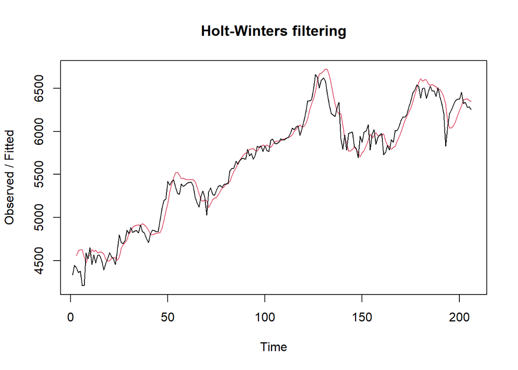

```r
#Beta=0.2 dan Alpha=0.3
des.1<- HoltWinters(train.ts, gamma = FALSE, beta = 0.2, alpha = 0.3)
plot(des.1)
```

```r
#ramalan
ramalandes1<- forecast(des.1, h=52)
ramalandes1
```

```
##     Point Forecast    Lo 80    Hi 80    Lo 95     Hi 95
## 207       6320.469 6150.398 6490.540 6060.368  6580.571
## 208       6321.813 6141.057 6502.569 6045.371  6598.256
## 209       6323.157 6128.800 6517.515 6025.913  6620.402
## 210       6324.502 6113.696 6535.308 6002.102  6646.902
## 211       6325.846 6095.904 6555.788 5974.179  6677.512
## 212       6327.190 6075.623 6578.757 5942.451  6711.929
## 213       6328.534 6053.061 6604.007 5907.234  6749.834
## 214       6329.878 6028.415 6631.341 5868.831  6790.926
## 215       6331.222 6001.863 6660.581 5827.511  6834.934
## 216       6332.567 5973.559 6691.574 5783.512  6881.621
## 217       6333.911 5943.635 6724.186 5737.036  6930.785
## 218       6335.255 5912.205 6758.305 5688.255  6982.254
## 219       6336.599 5879.364 6793.834 5637.318  7035.880
## 220       6337.943 5845.194 6830.692 5584.349  7091.537
```

[output cut: 38 more lines]

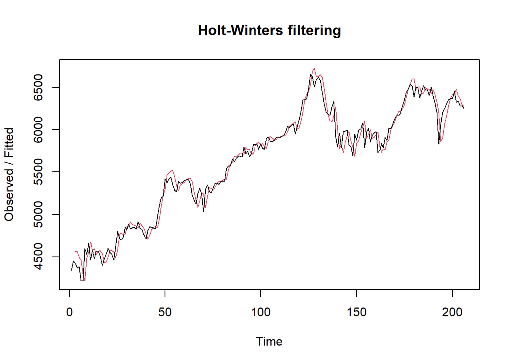

```r
#Beta=0.3 dan Alpha=0.6
des.2<- HoltWinters(train.ts, gamma = FALSE, beta = 0.3, alpha = 0.6)
plot(des.2)
```

```r
#ramalan
ramalandes2<- forecast(des.2, h=52)
ramalandes2
```

```
##     Point Forecast     Lo 80     Hi 80       Lo 95     Hi 95
## 207       6243.316 6101.3752  6385.256  6026.23653  6460.395
## 208       6222.945 6042.9323  6402.958  5947.63933  6498.251
## 209       6202.574 5976.8042  6428.344  5857.28878  6547.860
## 210       6182.204 5904.4352  6459.972  5757.39353  6607.014
## 211       6161.833 5826.7813  6496.884  5649.41577  6674.250
## 212       6141.462 5744.4855  6538.439  5534.33878  6748.586
## 213       6121.092 5658.0002  6584.183  5412.85441  6829.329
## 214       6100.721 5567.6594  6633.782  5285.47378  6915.968
## 215       6080.350 5473.7213  6686.979  5152.59139  7008.109
## 216       6059.979 5376.3923  6743.567  5014.52307  7105.436
## 217       6039.609 5275.8427  6803.375  4871.52933  7207.688
## 218       6019.238 5172.2164  6866.260  4723.83025  7314.646
## 219       5998.867 5065.6374  6932.097  4571.61538  7426.119
## 220       5978.497 4956.2142  7000.779  4415.05060  7541.943
```

[output cut: 38 more lines]

Selanjutnya jika ingin membandingkan plot data latih dan data uji adalah sebagai berikut.

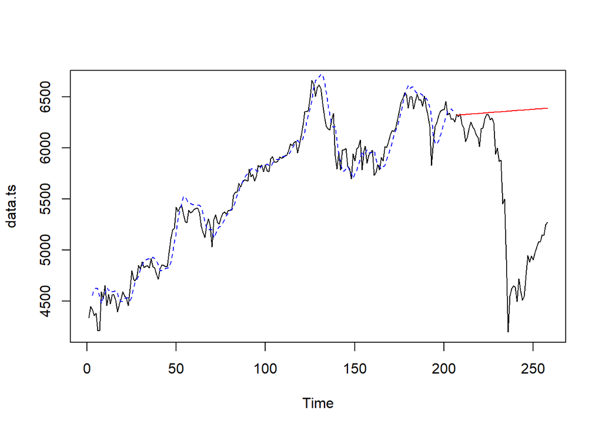

```r
plot(data.ts)
lines(des.1$fitted[,1], lty=2, col="blue")
lines(ramalandes1$mean, col="red")
```

Untuk mendapatkan nilai parameter optimum dari DES, argumen `alpha` dan `beta` dapat dibuat `NULL` seperti berikut.

```r
#Beta dan Alpha optimum
des.opt<- HoltWinters(train.ts, gamma = FALSE)
des.opt
```

```
## Holt-Winters exponential smoothing with trend and without seasonal component.
##
## Call:
## HoltWinters(x = train.ts, gamma = FALSE)
##
## Smoothing parameters:
##  alpha: 0.879714
##  beta : 0.06790277
##  gamma: FALSE
##
## Coefficients:
##          [,1]
## a 6259.266091
## b   -2.643623
```

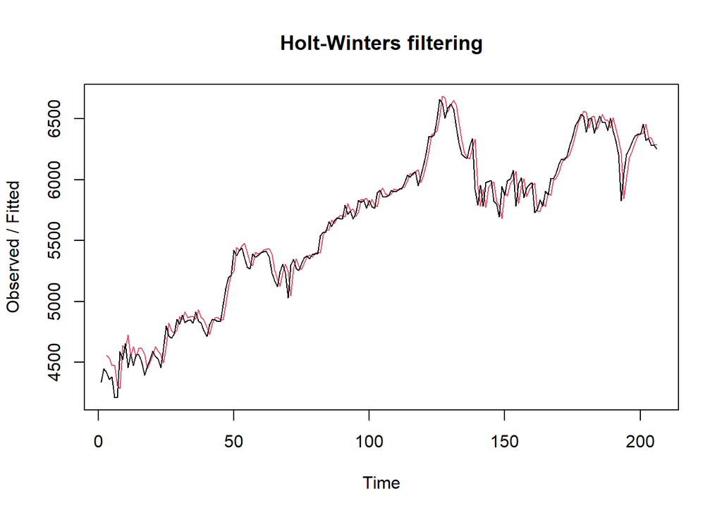

```r
plot(des.opt)
```

```r
#ramalan
ramalandesopt<- forecast(des.opt, h=52)
ramalandesopt
```

```
##     Point Forecast    Lo 80    Hi 80    Lo 95    Hi 95
## 207       6256.622 6122.264 6390.981 6051.139 6462.106
## 208       6253.979 6069.630 6438.327 5972.042 6535.915
## 209       6251.335 6023.285 6479.386 5902.562 6600.108
## 210       6248.692 5979.900 6517.484 5837.610 6659.773
## 211       6246.048 5938.088 6554.008 5775.064 6717.032
## 212       6243.404 5897.129 6589.680 5713.822 6772.987
## 213       6240.761 5856.600 6624.922 5653.237 6828.284
## 214       6238.117 5816.232 6660.003 5592.899 6883.335
## 215       6235.473 5775.845 6695.102 5532.532 6938.415
## 216       6232.830 5735.314 6730.346 5471.945 6993.715
## 217       6230.186 5694.549 6765.823 5411.000 7049.372
## 218       6227.543 5653.485 6801.600 5349.598 7105.487
## 219       6224.899 5612.073 6837.725 5287.663 7162.135
## 220       6222.255 5570.277 6874.234 5225.140 7219.371
```

[output cut: 38 more lines]

Selanjutnya akan dilakukan perhitungan akurasi pada data latih maupun data uji dengan ukuran akurasi SSE, MSE dan MAPE.

### Akurasi Data Latih

```r
#Akurasi Data Training
ssedes.train1<-des.1$SSE
msedes.train1<-ssedes.train1/length(train.ts)
sisaandes1<-ramalandes1$residuals
head(sisaandes1)
```

```
## Time Series:
## Start = 1
## End = 6
## Frequency = 1
## [1]        NA        NA -141.1011 -255.4214 -245.3962 -414.3799
```

```r
mapedes.train1 <- sum(abs(sisaandes1[3:length(train.ts)]/train.ts[3:length(train.ts)])
                      *100)/length(train.ts)

akurasides.1 <- matrix(c(ssedes.train1,msedes.train1,mapedes.train1))
row.names(akurasides.1)<- c("SSE", "MSE", "MAPE")
colnames(akurasides.1) <- c("Akurasi Beta=0.2 dan Alpha=0.3")
akurasides.1
```

```
##      Akurasi Beta=0.2 dan Alpha=0.3
## SSE                    3.591224e+06
## MSE                    1.743313e+04
## MAPE                   1.801555e+00
```

```r
ssedes.train2<-des.2$SSE
msedes.train2<-ssedes.train2/length(train.ts)
sisaandes2<-ramalandes2$residuals
head(sisaandes2)
```

```
## Time Series:
## Start = 1
## End = 6
## Frequency = 1
## [1]        NA        NA -141.1011 -196.1589 -108.1494 -244.2037
```

```r
mapedes.train2 <- sum(abs(sisaandes2[3:length(train.ts)]/train.ts[3:length(train.ts)])
                      *100)/length(train.ts)

akurasides.2 <- matrix(c(ssedes.train2,msedes.train2,mapedes.train2))
row.names(akurasides.2)<- c("SSE", "MSE", "MAPE")
colnames(akurasides.2) <- c("Akurasi Beta=0.3 dan Alpha=0.6")
akurasides.2
```

```
##      Akurasi Beta=0.3 dan Alpha=0.6
## SSE                    2.492791e+06
## MSE                    1.210093e+04
## MAPE                   1.467946e+00
```

Hasil akurasi dari data latih didapatkan skenario 2 dengan alpha=0.6 dan beta=0.3 memiliki hasil yang lebih baik. Namun untuk kedua skenario dapat dikategorikan peramalan sangat baik berdasarkan nilai MAPE-nya.

### Akurasi Data Uji

```r
#Akurasi Data Testing
selisihdes1<-ramalandes1$mean-testing$`Close`
selisihdes1
```

```
## Time Series:
## Start = 207
## End = 258
## Frequency = 1
##  [1]   -8.001029   12.863141  -11.685286   93.028494  128.956629  265.937987
##  [7]  222.734286  137.931465   78.877178  125.375626  155.924855  206.909630
## [13]  236.356809  326.113069  152.419134  143.313578   57.603529   14.005786
## [19]   21.198081   71.067134   55.694976  104.587467  409.992653  351.777722
## [25]  485.783982  471.818075  902.713007  858.221220 1450.534609 2164.505713
## [31] 1815.222911 1738.708663 1714.402912 1730.005363 1870.106350 1651.111634
## [37] 1771.428441 1862.595834 1825.594770 1619.279253 1426.452994 1495.220484
## [43] 1434.648620 1474.179782 1405.817878 1349.700115 1302.715164 1300.653065
## [49] 1235.361474 1242.439512 1139.986787 1116.210821
```

```r
SSEtestingdes1<-sum(selisihdes1^2)
MSEtestingdes1<-SSEtestingdes1/length(testing$`Close`)
MAPEtestingdes1<-sum(abs(selisihdes1/testing$`Close`)*100)/length(testing$`Close`)

selisihdes2<-ramalandes2$mean-testing$`Close`
selisihdes2
```

```
## Time Series:
## Start = 207
## End = 258
## Frequency = 1
##  [1]  -85.15455  -86.00522 -132.26849  -49.26955  -35.05626   80.21025
##  [7]   15.29171  -91.22596 -171.99509 -147.21148 -138.37710 -109.10716
## [13] -101.37483  -33.33341 -228.74219 -259.56259 -366.98748 -432.30007
## [19] -446.82262 -418.66841 -455.75541 -428.57776 -144.88742 -224.81719
## [25] -112.52577 -148.20652  260.97356  194.76693  765.36548 1457.62174
## [31] 1086.62410  988.39501  942.37441  936.26202 1054.64816  813.93860
## [37]  912.54057  981.99312  923.27721  695.24685  480.70575  527.75839
## [43]  445.47169  463.28801  373.21126  295.37865  226.67886  202.90192
## [49]  115.89548  101.25868  -22.90889  -68.39970
```

```r
SSEtestingdes2<-sum(selisihdes2^2)
MSEtestingdes2<-SSEtestingdes2/length(testing$`Close`)
MAPEtestingdes2<-sum(abs(selisihdes2/testing$`Close`)*100)/length(testing$`Close`)

selisihdesopt<-ramalandesopt$mean-testing$`Close`
selisihdesopt
```

```
## Time Series:
## Start = 207
## End = 258
## Frequency = 1
##  [1]  -71.84775  -54.97135  -83.50755   17.21845   49.15881  182.15240
##  [7]  134.96092   46.17033  -16.87173   25.63894   52.20039   99.19740
## [13]  124.65680  210.42529   32.74358   19.65025  -70.04758 -117.63309
## [19] -114.42857  -68.54729  -87.90722  -43.00251  258.41490  196.21220
## [25]  326.23068  308.27700  735.18416  686.70460 1275.03021 1985.01354
## [31] 1631.74297 1551.24095 1522.94742 1534.56210 1670.67531 1447.69282
## [37] 1564.02185 1651.20147 1610.21263 1399.90934 1203.09531 1267.87503
## [43] 1203.31539 1238.85878 1166.50910 1106.40356 1055.43084 1049.38096
## [49]  980.10160  983.19186  876.75136  848.98762
```

```r
SSEtestingdesopt<-sum(selisihdesopt^2)
MSEtestingdesopt<-SSEtestingdesopt/length(testing$`Close`)
MAPEtestingdesopt<-sum(abs(selisihdesopt/testing$`Close`)*100)/length(testing$`Close`)

akurasitestingdes <-
  matrix(c(SSEtestingdes1,MSEtestingdes1,MAPEtestingdes1,SSEtestingdes2,MSEtestingdes2,
           MAPEtestingdes2,SSEtestingdesopt,MSEtestingdesopt,MAPEtestingdesopt),
         nrow=3,ncol=3)
row.names(akurasitestingdes)<- c("SSE", "MSE", "MAPE")
colnames(akurasitestingdes) <- c("des ske1","des ske2","des opt")
akurasitestingdes
```

```
##          des ske1     des ske2      des opt
## SSE  6.191384e+07 1.437534e+07 4.568682e+07
## MSE  1.190651e+06 2.764489e+05 8.785926e+05
## MAPE 1.699031e+01 7.847403e+00 1.426854e+01
```

## Perbandingan SES dan DES

```r
MSEfull <-
  matrix(c(MSEtesting1,MSEtesting2,MSEtestingopt,MSEtestingdes1,MSEtestingdes2,
           MSEtestingdesopt),nrow=3,ncol=2)
row.names(MSEfull)<- c("ske 1", "ske 2", "ske opt")
colnames(MSEfull) <- c("ses","des")
MSEfull
```

```
##             ses       des
## ske 1   1076596 1190650.7
## ske 2   1028861  276448.9
## ske opt 1019868  878592.6
```

# Kesimpulan

Berdasarkan berbagai macam cara untuk forecasting yang telah dilakukan, hasil dari DES (Double Exponentila Smoothing) dengan nilai Beta 0,3 dan Alpha 0,6 merupakan model yang terbaik dibandingkan dengan model yang lainnya.